# Risk Factor Analysis

## Outcome Variable

**Outcome Variable:** y_rate_haz

## Predictor Variables

**Intervention Variable:** fhtcm

**Adjustment Set:**

unadjusted

## Stratifying Variables

The analysis was stratified on these variable(s):

- agecat
- studyid
- country

## Data Summary

| agecat | studyid | country | fhtcm | n_cell | n |
| --- | --- | --- | --- | --- | --- |
| 0-3 months | ki1000304b-SAS-CompFeed | INDIA | >=167 cm | 94 | 212 |
| 0-3 months | ki1000304b-SAS-CompFeed | INDIA | <162 cm | 53 | 212 |
| 0-3 months | ki1000304b-SAS-CompFeed | INDIA | [162-167) cm | 65 | 212 |
| 0-3 months | ki1101329-Keneba | GAMBIA | >=167 cm | 631 | 965 |
| 0-3 months | ki1101329-Keneba | GAMBIA | <162 cm | 75 | 965 |
| 0-3 months | ki1101329-Keneba | GAMBIA | [162-167) cm | 259 | 965 |
| 0-3 months | ki1119695-PROBIT | BELARUS | >=167 cm | 5492 | 5879 |
| 0-3 months | ki1119695-PROBIT | BELARUS | <162 cm | 76 | 5879 |
| 0-3 months | ki1119695-PROBIT | BELARUS | [162-167) cm | 311 | 5879 |
| 0-3 months | ki1135781-COHORTS | GUATEMALA | >=167 cm | 12 | 81 |
| 0-3 months | ki1135781-COHORTS | GUATEMALA | <162 cm | 39 | 81 |
| 0-3 months | ki1135781-COHORTS | GUATEMALA | [162-167) cm | 30 | 81 |
| 3-6 months | ki1000304b-SAS-CompFeed | INDIA | >=167 cm | 83 | 187 |
| 3-6 months | ki1000304b-SAS-CompFeed | INDIA | <162 cm | 48 | 187 |
| 3-6 months | ki1000304b-SAS-CompFeed | INDIA | [162-167) cm | 56 | 187 |
| 3-6 months | ki1101329-Keneba | GAMBIA | >=167 cm | 673 | 1037 |
| 3-6 months | ki1101329-Keneba | GAMBIA | <162 cm | 74 | 1037 |
| 3-6 months | ki1101329-Keneba | GAMBIA | [162-167) cm | 290 | 1037 |
| 3-6 months | ki1119695-PROBIT | BELARUS | >=167 cm | 4945 | 5292 |
| 3-6 months | ki1119695-PROBIT | BELARUS | <162 cm | 69 | 5292 |
| 3-6 months | ki1119695-PROBIT | BELARUS | [162-167) cm | 278 | 5292 |
| 3-6 months | ki1135781-COHORTS | GUATEMALA | >=167 cm | 18 | 117 |
| 3-6 months | ki1135781-COHORTS | GUATEMALA | <162 cm | 61 | 117 |
| 3-6 months | ki1135781-COHORTS | GUATEMALA | [162-167) cm | 38 | 117 |
| 6-9 months | ki1000304b-SAS-CompFeed | INDIA | >=167 cm | 81 | 180 |
| 6-9 months | ki1000304b-SAS-CompFeed | INDIA | <162 cm | 43 | 180 |
| 6-9 months | ki1000304b-SAS-CompFeed | INDIA | [162-167) cm | 56 | 180 |
| 6-9 months | ki1000304b-SAS-FoodSuppl | INDIA | >=167 cm | 15 | 73 |
| 6-9 months | ki1000304b-SAS-FoodSuppl | INDIA | <162 cm | 27 | 73 |
| 6-9 months | ki1000304b-SAS-FoodSuppl | INDIA | [162-167) cm | 31 | 73 |

[output cut: 72 more lines]

The following strata were considered:

- agecat: 0-3 months, studyid: ki1000304b-SAS-CompFeed, country: INDIA
- agecat: 0-3 months, studyid: ki1101329-Keneba, country: GAMBIA
- agecat: 0-3 months, studyid: ki1119695-PROBIT, country: BELARUS
- agecat: 0-3 months, studyid: ki1135781-COHORTS, country: GUATEMALA
- agecat: 12-15 months, studyid: ki1000304b-SAS-CompFeed, country: INDIA
- agecat: 12-15 months, studyid: ki1000304b-SAS-FoodSuppl, country: INDIA
- agecat: 12-15 months, studyid: ki1101329-Keneba, country: GAMBIA
- agecat: 12-15 months, studyid: ki1119695-PROBIT, country: BELARUS
- agecat: 12-15 months, studyid: ki1135781-COHORTS, country: GUATEMALA
- agecat: 15-18 months, studyid: ki1000304b-SAS-CompFeed, country: INDIA
- agecat: 15-18 months, studyid: ki1000304b-SAS-FoodSuppl, country: INDIA
- agecat: 15-18 months, studyid: ki1101329-Keneba, country: GAMBIA
- agecat: 15-18 months, studyid: ki1119695-PROBIT, country: BELARUS
- agecat: 15-18 months, studyid: ki1135781-COHORTS, country: GUATEMALA
- agecat: 18-21 months, studyid: ki1101329-Keneba, country: GAMBIA
- agecat: 18-21 months, studyid: ki1119695-PROBIT, country: BELARUS
- agecat: 18-21 months, studyid: ki1135781-COHORTS, country: GUATEMALA
- agecat: 21-24 months, studyid: ki1101329-Keneba, country: GAMBIA
- agecat: 21-24 months, studyid: ki1119695-PROBIT, country: BELARUS
- agecat: 21-24 months, studyid: ki1135781-COHORTS, country: GUATEMALA
- agecat: 3-6 months, studyid: ki1000304b-SAS-CompFeed, country: INDIA
- agecat: 3-6 months, studyid: ki1101329-Keneba, country: GAMBIA
- agecat: 3-6 months, studyid: ki1119695-PROBIT, country: BELARUS
- agecat: 3-6 months, studyid: ki1135781-COHORTS, country: GUATEMALA
- agecat: 6-9 months, studyid: ki1000304b-SAS-CompFeed, country: INDIA
- agecat: 6-9 months, studyid: ki1000304b-SAS-FoodSuppl, country: INDIA
- agecat: 6-9 months, studyid: ki1101329-Keneba, country: GAMBIA
- agecat: 6-9 months, studyid: ki1119695-PROBIT, country: BELARUS
- agecat: 6-9 months, studyid: ki1135781-COHORTS, country: GUATEMALA
- agecat: 9-12 months, studyid: ki1000304b-SAS-CompFeed, country: INDIA
- agecat: 9-12 months, studyid: ki1000304b-SAS-FoodSuppl, country: INDIA
- agecat: 9-12 months, studyid: ki1101329-Keneba, country: GAMBIA
- agecat: 9-12 months, studyid: ki1119695-PROBIT, country: BELARUS
- agecat: 9-12 months, studyid: ki1135781-COHORTS, country: GUATEMALA

### Dropped Strata

Some strata were dropped due to rare outcomes:

- agecat: 12-15 months, studyid: ki1119695-PROBIT, country: BELARUS
- agecat: 15-18 months, studyid: ki1119695-PROBIT, country: BELARUS
- agecat: 18-21 months, studyid: ki1119695-PROBIT, country: BELARUS
- agecat: 21-24 months, studyid: ki1119695-PROBIT, country: BELARUS

## Methods Detail

We’re interested in the causal parameters $E[Y_a]$ for all values of $a \in \mathcal{A}$. These parameters represent the mean outcome if, possibly contrary to fact, we intervened to set all units to have $A=a$. Under the randomization and positivity assumptions, these are identified by the statistical parameters $\psi_a=E_W[E_{Y|A,W}(Y|A=a,W)]$. In addition, we’re interested in the mean of $Y$, $E[Y]$ under no intervention (the observed mean). We will estimate these parameters by using SuperLearner to fit the relevant likelihood factors – $E_{Y|A,W}(Y|A=a,W)$ and $p(A=a|W)$, and then updating our likelihood fit using a joint TMLE.

For unadjusted analyses ($W=\{\}$), initial likelihoods were estimated using Lrnr_glm to estimate the simple $E(Y|A)$ and Lrnr_mean to estimate $p(A)$. For adjusted analyses, a small library containing Lrnr_glmnet, Lrnr_xgboost, and Lrnr_mean was used.

Having estimated these parameters, we will then use the delta method to estimate relative risks and attributable risks relative to a prespecified baseline level of $A$.

# Results Detail

## Results Plots

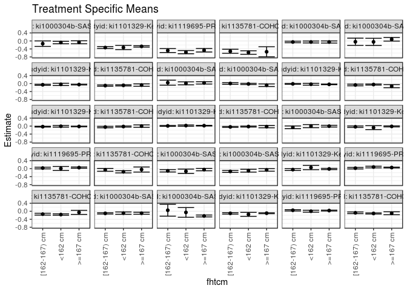

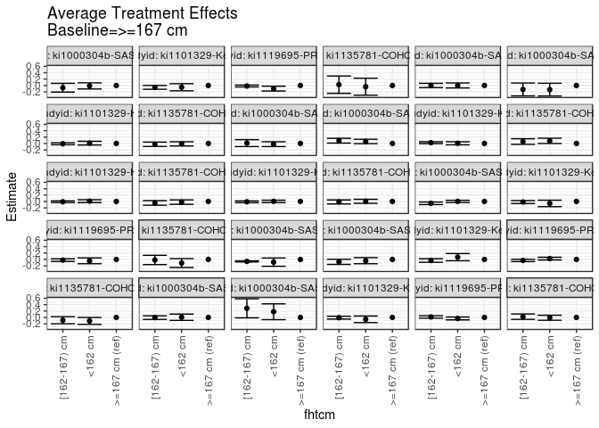

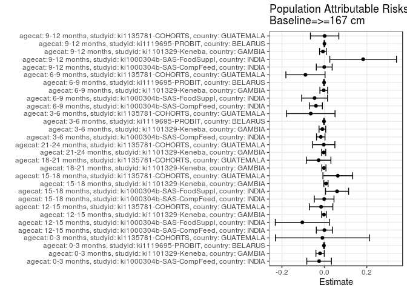

## Results Table

### Parameter: TSM

| agecat | studyid | country | intervention_level | baseline_level | estimate | ci_lower | ci_upper |
| --- | --- | --- | --- | --- | --- | --- | --- |
| 0-3 months | ki1000304b-SAS-CompFeed | INDIA | >=167 cm | NA | -0.0667148 | -0.1407638 | 0.0073342 |
| 0-3 months | ki1000304b-SAS-CompFeed | INDIA | <162 cm | NA | -0.0798556 | -0.1416123 | -0.0180989 |
| 0-3 months | ki1000304b-SAS-CompFeed | INDIA | [162-167) cm | NA | -0.1364988 | -0.2738244 | 0.0008269 |
| 0-3 months | ki1101329-Keneba | GAMBIA | >=167 cm | NA | -0.2725020 | -0.3077510 | -0.2372530 |
| 0-3 months | ki1101329-Keneba | GAMBIA | <162 cm | NA | -0.3275281 | -0.4334342 | -0.2216221 |
| 0-3 months | ki1101329-Keneba | GAMBIA | [162-167) cm | NA | -0.3312793 | -0.3792425 | -0.2833161 |
| 0-3 months | ki1119695-PROBIT | BELARUS | >=167 cm | NA | -0.4647069 | -0.5523337 | -0.3770802 |
| 0-3 months | ki1119695-PROBIT | BELARUS | <162 cm | NA | -0.5622480 | -0.6415420 | -0.4829539 |
| 0-3 months | ki1119695-PROBIT | BELARUS | [162-167) cm | NA | -0.4806048 | -0.5805436 | -0.3806659 |
| 0-3 months | ki1135781-COHORTS | GUATEMALA | >=167 cm | NA | -0.5420412 | -0.7931910 | -0.2908914 |
| 0-3 months | ki1135781-COHORTS | GUATEMALA | <162 cm | NA | -0.5807370 | -0.6687739 | -0.4927001 |
| 0-3 months | ki1135781-COHORTS | GUATEMALA | [162-167) cm | NA | -0.5164154 | -0.6182069 | -0.4146239 |
| 3-6 months | ki1000304b-SAS-CompFeed | INDIA | >=167 cm | NA | -0.0030554 | -0.0474001 | 0.0412892 |
| 3-6 months | ki1000304b-SAS-CompFeed | INDIA | <162 cm | NA | -0.0012621 | -0.0788355 | 0.0763113 |
| 3-6 months | ki1000304b-SAS-CompFeed | INDIA | [162-167) cm | NA | -0.0609381 | -0.1293906 | 0.0075143 |
| 3-6 months | ki1101329-Keneba | GAMBIA | >=167 cm | NA | -0.0150521 | -0.0404454 | 0.0103411 |
| 3-6 months | ki1101329-Keneba | GAMBIA | <162 cm | NA | -0.0762347 | -0.1744078 | 0.0219384 |
| 3-6 months | ki1101329-Keneba | GAMBIA | [162-167) cm | NA | -0.0326117 | -0.0716051 | 0.0063818 |
| 3-6 months | ki1119695-PROBIT | BELARUS | >=167 cm | NA | 0.0531978 | 0.0224067 | 0.0839889 |
| 3-6 months | ki1119695-PROBIT | BELARUS | <162 cm | NA | 0.0104273 | -0.0904617 | 0.1113164 |
| 3-6 months | ki1119695-PROBIT | BELARUS | [162-167) cm | NA | 0.0323491 | -0.0105124 | 0.0752105 |
| 3-6 months | ki1135781-COHORTS | GUATEMALA | >=167 cm | NA | -0.0431638 | -0.1705764 | 0.0842488 |
| 3-6 months | ki1135781-COHORTS | GUATEMALA | <162 cm | NA | -0.1563111 | -0.2123596 | -0.1002625 |
| 3-6 months | ki1135781-COHORTS | GUATEMALA | [162-167) cm | NA | -0.0587279 | -0.1285844 | 0.0111286 |
| 6-9 months | ki1000304b-SAS-CompFeed | INDIA | >=167 cm | NA | -0.0450240 | -0.1042714 | 0.0142233 |
| 6-9 months | ki1000304b-SAS-CompFeed | INDIA | <162 cm | NA | -0.1304955 | -0.2400223 | -0.0209686 |
| 6-9 months | ki1000304b-SAS-CompFeed | INDIA | [162-167) cm | NA | -0.1066718 | -0.1646643 | -0.0486794 |
| 6-9 months | ki1000304b-SAS-FoodSuppl | INDIA | >=167 cm | NA | -0.0620523 | -0.1256423 | 0.0015377 |
| 6-9 months | ki1000304b-SAS-FoodSuppl | INDIA | <162 cm | NA | -0.1007355 | -0.1720353 | -0.0294356 |
| 6-9 months | ki1000304b-SAS-FoodSuppl | INDIA | [162-167) cm | NA | -0.1366949 | -0.1848739 | -0.0885159 |

[output cut: 60 more lines]

### Parameter: E(Y)

| agecat | studyid | country | intervention_level | baseline_level | estimate | ci_lower | ci_upper |
| --- | --- | --- | --- | --- | --- | --- | --- |
| 0-3 months | ki1000304b-SAS-CompFeed | INDIA | NA | NA | -0.0913960 | -0.1548167 | -0.0279753 |
| 0-3 months | ki1101329-Keneba | GAMBIA | NA | NA | -0.2925541 | -0.3202623 | -0.2648459 |
| 0-3 months | ki1119695-PROBIT | BELARUS | NA | NA | -0.4668089 | -0.5550752 | -0.3785425 |
| 0-3 months | ki1135781-COHORTS | GUATEMALA | NA | NA | -0.5511815 | -0.6193340 | -0.4830290 |
| 3-6 months | ki1000304b-SAS-CompFeed | INDIA | NA | NA | -0.0199290 | -0.0809943 | 0.0411364 |
| 3-6 months | ki1101329-Keneba | GAMBIA | NA | NA | -0.0243287 | -0.0453184 | -0.0033389 |
| 3-6 months | ki1119695-PROBIT | BELARUS | NA | NA | 0.0515449 | 0.0204515 | 0.0826383 |
| 3-6 months | ki1135781-COHORTS | GUATEMALA | NA | NA | -0.1072101 | -0.1501138 | -0.0643064 |
| 6-9 months | ki1000304b-SAS-CompFeed | INDIA | NA | NA | -0.0846215 | -0.1281707 | -0.0410724 |
| 6-9 months | ki1000304b-SAS-FoodSuppl | INDIA | NA | NA | -0.1080573 | -0.1444937 | -0.0716210 |
| 6-9 months | ki1101329-Keneba | GAMBIA | NA | NA | -0.0162599 | -0.0424084 | 0.0098886 |
| 6-9 months | ki1119695-PROBIT | BELARUS | NA | NA | 0.0555056 | 0.0349845 | 0.0760267 |
| 6-9 months | ki1135781-COHORTS | GUATEMALA | NA | NA | -0.1451633 | -0.1739608 | -0.1163658 |
| 9-12 months | ki1000304b-SAS-CompFeed | INDIA | NA | NA | -0.1003130 | -0.1216935 | -0.0789325 |
| 9-12 months | ki1000304b-SAS-FoodSuppl | INDIA | NA | NA | -0.0522847 | -0.2053342 | 0.1007648 |
| 9-12 months | ki1101329-Keneba | GAMBIA | NA | NA | -0.1043948 | -0.1248389 | -0.0839507 |
| 9-12 months | ki1119695-PROBIT | BELARUS | NA | NA | 0.0347415 | 0.0121962 | 0.0572867 |
| 9-12 months | ki1135781-COHORTS | GUATEMALA | NA | NA | -0.0989624 | -0.1218053 | -0.0761196 |
| 12-15 months | ki1000304b-SAS-CompFeed | INDIA | NA | NA | -0.0522937 | -0.0834078 | -0.0211795 |
| 12-15 months | ki1000304b-SAS-FoodSuppl | INDIA | NA | NA | -0.0194561 | -0.1246771 | 0.0857649 |
| 12-15 months | ki1101329-Keneba | GAMBIA | NA | NA | -0.0546831 | -0.0687903 | -0.0405758 |
| 12-15 months | ki1135781-COHORTS | GUATEMALA | NA | NA | -0.0937250 | -0.1145338 | -0.0729162 |
| 15-18 months | ki1000304b-SAS-CompFeed | INDIA | NA | NA | 0.0309027 | -0.0393007 | 0.1011061 |
| 15-18 months | ki1000304b-SAS-FoodSuppl | INDIA | NA | NA | -0.0247238 | -0.0497697 | 0.0003221 |
| 15-18 months | ki1101329-Keneba | GAMBIA | NA | NA | -0.0340694 | -0.0467538 | -0.0213851 |
| 15-18 months | ki1135781-COHORTS | GUATEMALA | NA | NA | -0.0690427 | -0.0917763 | -0.0463092 |
| 18-21 months | ki1101329-Keneba | GAMBIA | NA | NA | -0.0200780 | -0.0325402 | -0.0076159 |
| 18-21 months | ki1135781-COHORTS | GUATEMALA | NA | NA | -0.0279393 | -0.0489434 | -0.0069353 |
| 21-24 months | ki1101329-Keneba | GAMBIA | NA | NA | 0.0182744 | 0.0054117 | 0.0311371 |
| 21-24 months | ki1135781-COHORTS | GUATEMALA | NA | NA | -0.0294229 | -0.0465918 | -0.0122539 |

### Parameter: ATE

| agecat | studyid | country | intervention_level | baseline_level | estimate | ci_lower | ci_upper |
| --- | --- | --- | --- | --- | --- | --- | --- |
| 0-3 months | ki1000304b-SAS-CompFeed | INDIA | >=167 cm | >=167 cm | 0.0000000 | 0.0000000 | 0.0000000 |
| 0-3 months | ki1000304b-SAS-CompFeed | INDIA | <162 cm | >=167 cm | -0.0131408 | -0.1089261 | 0.0826444 |
| 0-3 months | ki1000304b-SAS-CompFeed | INDIA | [162-167) cm | >=167 cm | -0.0697840 | -0.2063258 | 0.0667578 |
| 0-3 months | ki1101329-Keneba | GAMBIA | >=167 cm | >=167 cm | 0.0000000 | 0.0000000 | 0.0000000 |
| 0-3 months | ki1101329-Keneba | GAMBIA | <162 cm | >=167 cm | -0.0550261 | -0.1666442 | 0.0565919 |
| 0-3 months | ki1101329-Keneba | GAMBIA | [162-167) cm | >=167 cm | -0.0587773 | -0.1183001 | 0.0007455 |
| 0-3 months | ki1119695-PROBIT | BELARUS | >=167 cm | >=167 cm | 0.0000000 | 0.0000000 | 0.0000000 |
| 0-3 months | ki1119695-PROBIT | BELARUS | <162 cm | >=167 cm | -0.0975410 | -0.1728961 | -0.0221860 |
| 0-3 months | ki1119695-PROBIT | BELARUS | [162-167) cm | >=167 cm | -0.0158978 | -0.0460083 | 0.0142126 |
| 0-3 months | ki1135781-COHORTS | GUATEMALA | >=167 cm | >=167 cm | 0.0000000 | 0.0000000 | 0.0000000 |
| 0-3 months | ki1135781-COHORTS | GUATEMALA | <162 cm | >=167 cm | -0.0386958 | -0.3048287 | 0.2274371 |
| 0-3 months | ki1135781-COHORTS | GUATEMALA | [162-167) cm | >=167 cm | 0.0256258 | -0.2453681 | 0.2966197 |
| 3-6 months | ki1000304b-SAS-CompFeed | INDIA | >=167 cm | >=167 cm | 0.0000000 | 0.0000000 | 0.0000000 |
| 3-6 months | ki1000304b-SAS-CompFeed | INDIA | <162 cm | >=167 cm | 0.0017933 | -0.0326996 | 0.0362863 |
| 3-6 months | ki1000304b-SAS-CompFeed | INDIA | [162-167) cm | >=167 cm | -0.0578827 | -0.0981625 | -0.0176028 |
| 3-6 months | ki1101329-Keneba | GAMBIA | >=167 cm | >=167 cm | 0.0000000 | 0.0000000 | 0.0000000 |
| 3-6 months | ki1101329-Keneba | GAMBIA | <162 cm | >=167 cm | -0.0611826 | -0.1625866 | 0.0402215 |
| 3-6 months | ki1101329-Keneba | GAMBIA | [162-167) cm | >=167 cm | -0.0175595 | -0.0640924 | 0.0289734 |
| 3-6 months | ki1119695-PROBIT | BELARUS | >=167 cm | >=167 cm | 0.0000000 | 0.0000000 | 0.0000000 |
| 3-6 months | ki1119695-PROBIT | BELARUS | <162 cm | >=167 cm | -0.0427705 | -0.1338009 | 0.0482600 |
| 3-6 months | ki1119695-PROBIT | BELARUS | [162-167) cm | >=167 cm | -0.0208487 | -0.0609053 | 0.0192078 |
| 3-6 months | ki1135781-COHORTS | GUATEMALA | >=167 cm | >=167 cm | 0.0000000 | 0.0000000 | 0.0000000 |
| 3-6 months | ki1135781-COHORTS | GUATEMALA | <162 cm | >=167 cm | -0.1131473 | -0.2523428 | 0.0260483 |
| 3-6 months | ki1135781-COHORTS | GUATEMALA | [162-167) cm | >=167 cm | -0.0155641 | -0.1608703 | 0.1297421 |
| 6-9 months | ki1000304b-SAS-CompFeed | INDIA | >=167 cm | >=167 cm | 0.0000000 | 0.0000000 | 0.0000000 |
| 6-9 months | ki1000304b-SAS-CompFeed | INDIA | <162 cm | >=167 cm | -0.0854715 | -0.2148768 | 0.0439339 |
| 6-9 months | ki1000304b-SAS-CompFeed | INDIA | [162-167) cm | >=167 cm | -0.0616478 | -0.0781362 | -0.0451594 |
| 6-9 months | ki1000304b-SAS-FoodSuppl | INDIA | >=167 cm | >=167 cm | 0.0000000 | 0.0000000 | 0.0000000 |
| 6-9 months | ki1000304b-SAS-FoodSuppl | INDIA | <162 cm | >=167 cm | -0.0386832 | -0.1342204 | 0.0568540 |
| 6-9 months | ki1000304b-SAS-FoodSuppl | INDIA | [162-167) cm | >=167 cm | -0.0746426 | -0.1544230 | 0.0051377 |

[output cut: 60 more lines]

### Parameter: PAR

| agecat | studyid | country | intervention_level | baseline_level | estimate | ci_lower | ci_upper |
| --- | --- | --- | --- | --- | --- | --- | --- |
| 0-3 months | ki1000304b-SAS-CompFeed | INDIA | >=167 cm | NA | -0.0246812 | -0.0826793 | 0.0333168 |
| 0-3 months | ki1101329-Keneba | GAMBIA | >=167 cm | NA | -0.0200521 | -0.0396822 | -0.0004220 |
| 0-3 months | ki1119695-PROBIT | BELARUS | >=167 cm | NA | -0.0021019 | -0.0048116 | 0.0006077 |
| 0-3 months | ki1135781-COHORTS | GUATEMALA | >=167 cm | NA | -0.0091403 | -0.2305714 | 0.2122908 |
| 3-6 months | ki1000304b-SAS-CompFeed | INDIA | >=167 cm | NA | -0.0168735 | -0.0369081 | 0.0031611 |
| 3-6 months | ki1101329-Keneba | GAMBIA | >=167 cm | NA | -0.0092765 | -0.0250382 | 0.0064851 |
| 3-6 months | ki1119695-PROBIT | BELARUS | >=167 cm | NA | -0.0016529 | -0.0044602 | 0.0011544 |
| 3-6 months | ki1135781-COHORTS | GUATEMALA | >=167 cm | NA | -0.0640463 | -0.1784125 | 0.0503199 |
| 6-9 months | ki1000304b-SAS-CompFeed | INDIA | >=167 cm | NA | -0.0395975 | -0.0700072 | -0.0091878 |
| 6-9 months | ki1000304b-SAS-FoodSuppl | INDIA | >=167 cm | NA | -0.0460050 | -0.1069108 | 0.0149007 |
| 6-9 months | ki1101329-Keneba | GAMBIA | >=167 cm | NA | -0.0027216 | -0.0209503 | 0.0155070 |
| 6-9 months | ki1119695-PROBIT | BELARUS | >=167 cm | NA | -0.0013495 | -0.0034808 | 0.0007818 |
| 6-9 months | ki1135781-COHORTS | GUATEMALA | >=167 cm | NA | -0.0889307 | -0.1813110 | 0.0034495 |
| 9-12 months | ki1000304b-SAS-CompFeed | INDIA | >=167 cm | NA | -0.0005301 | -0.0379260 | 0.0368659 |
| 9-12 months | ki1000304b-SAS-FoodSuppl | INDIA | >=167 cm | NA | 0.1828645 | 0.0256723 | 0.3400566 |
| 9-12 months | ki1101329-Keneba | GAMBIA | >=167 cm | NA | -0.0066682 | -0.0224706 | 0.0091342 |
| 9-12 months | ki1119695-PROBIT | BELARUS | >=167 cm | NA | 0.0003888 | -0.0013813 | 0.0021588 |
| 9-12 months | ki1135781-COHORTS | GUATEMALA | >=167 cm | NA | 0.0013124 | -0.0656954 | 0.0683202 |
| 12-15 months | ki1000304b-SAS-CompFeed | INDIA | >=167 cm | NA | 0.0003902 | -0.0379901 | 0.0387705 |
| 12-15 months | ki1000304b-SAS-FoodSuppl | INDIA | >=167 cm | NA | -0.1037198 | -0.2311366 | 0.0236971 |
| 12-15 months | ki1101329-Keneba | GAMBIA | >=167 cm | NA | -0.0019478 | -0.0129490 | 0.0090535 |
| 12-15 months | ki1135781-COHORTS | GUATEMALA | >=167 cm | NA | -0.0152788 | -0.0706378 | 0.0400803 |
| 15-18 months | ki1000304b-SAS-CompFeed | INDIA | >=167 cm | NA | -0.0009421 | -0.0473280 | 0.0454438 |
| 15-18 months | ki1000304b-SAS-FoodSuppl | INDIA | >=167 cm | NA | 0.0598932 | 0.0055249 | 0.1142615 |
| 15-18 months | ki1101329-Keneba | GAMBIA | >=167 cm | NA | 0.0075515 | -0.0023988 | 0.0175017 |
| 15-18 months | ki1135781-COHORTS | GUATEMALA | >=167 cm | NA | 0.0633837 | -0.0068334 | 0.1336008 |
| 18-21 months | ki1101329-Keneba | GAMBIA | >=167 cm | NA | -0.0021626 | -0.0119194 | 0.0075942 |
| 18-21 months | ki1135781-COHORTS | GUATEMALA | >=167 cm | NA | -0.0269220 | -0.0847433 | 0.0308992 |
| 21-24 months | ki1101329-Keneba | GAMBIA | >=167 cm | NA | -0.0031096 | -0.0127468 | 0.0065275 |
| 21-24 months | ki1135781-COHORTS | GUATEMALA | >=167 cm | NA | -0.0028151 | -0.0552138 | 0.0495836 |